# 5장 탐색적 데이터 분석(EDA)

### 5.7 ggplot2 표현

이 장을 넘어가면 ggplot2 코드 표현을 더 간결하게 바꿀 것이다. 지금까지는 배우는 과정에 도움이 될 수 있도록 명시적인 코드를 사용하였다.

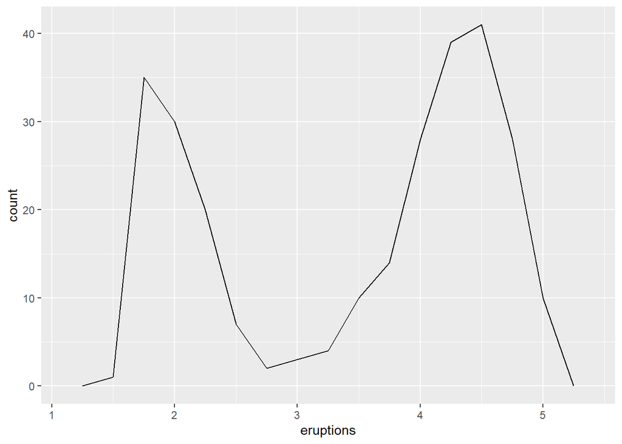

```r
# Old Faithful 분출 시간
ggplot(data = faithful, mapping = aes(x = eruptions)) +
  geom_freqpoly(binwidth = 0.25)
```

일반적으로 함수의 첫 번째, 두 번째 인수는 매우 중요하므로 기억해두어야 한다. ggplot()에서 처음 두 개의 인수는 data와 mapping 인수이며, aes()의 처음 두개의 인수는 x와 y이다.

이 책의 나머지 부분에서는 이 이름들을 쓰지 않을 것이다. 이렇게 하면 타이핑이 줄어들고 상용구의 양이 줄어들어 플롯 간에 다른 점을 쉽게 알 수 있다. 이는 15장에서 다루게 될 매우 중요한 프로그래밍 문제이다.

위의 플롯을 좀 더 간결하게 작성하면 다음과 같다.

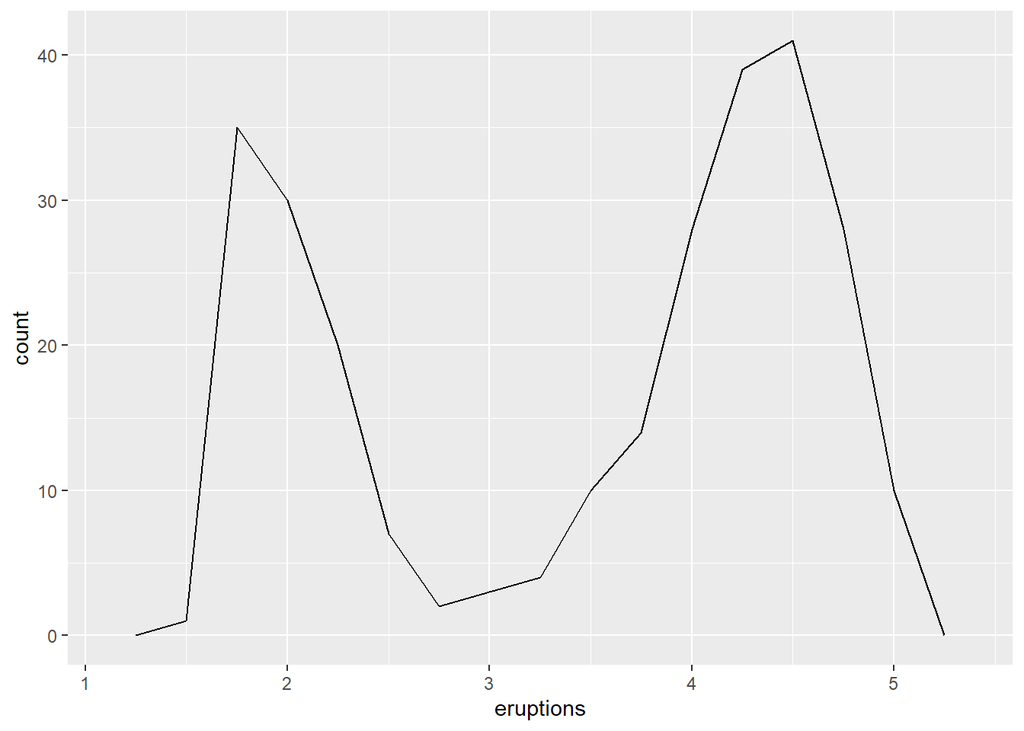

```r
ggplot(faithful, aes(eruptions)) +
  geom_freqpoly(binwidth = 0.25)
```

때때로 데이터를 변환하는 파이프라인의 끝을 플롯으로 전환할 것이다. %>%에서 +로 전환되는 것을 유의하자. 이 전환이 필요하지 않기를 바라지만 유감스럽게도 파이프를 발굴하기 이전에 ggplot2가 만들어졌다.

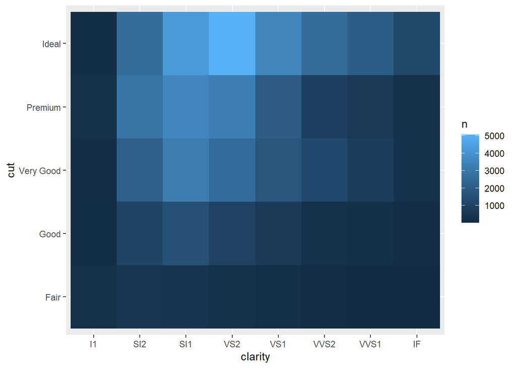

```r
diamonds %>%
   count(cut, clarity) %>%
ggplot(aes(clarity, cut, fill = n)) +
   geom_tile()
```

#### 결론

1. geom함수에 따라 시각화의 효과는 달라진다.
2. 데이터와 패턴의 상관관계가 일치해야 한다.
3. 시각화하는 방법은 관련된 변수의 유형에 따라 달라진다.